# hw2

|  | number_of_reviews | price | instant_bookable | room_type_Private room | room_type_Shared room |
| --- | --- | --- | --- | --- | --- |
| 0 | 150 | 59 | 0 | 1 | 0 |
| 1 | 20 | 230 | 0 | 0 | 0 |
| 2 | 0 | 150 | 0 | 1 | 0 |
| 3 | 116 | 89 | 0 | 0 | 0 |
| 4 | 93 | 39 | 1 | 1 | 0 |

Distributions

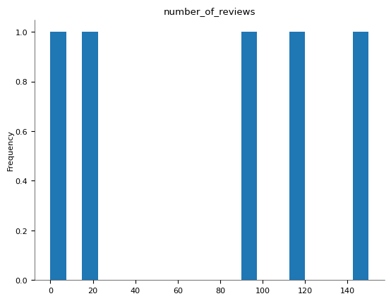

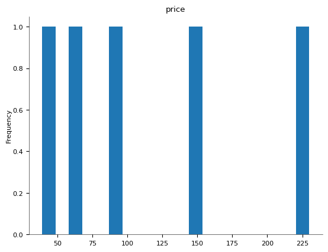

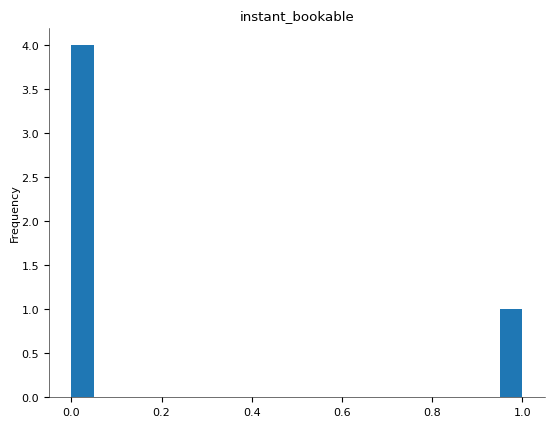

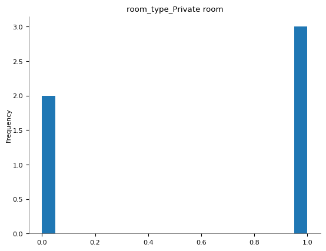

2-d distributions

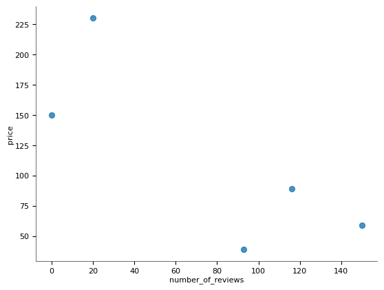

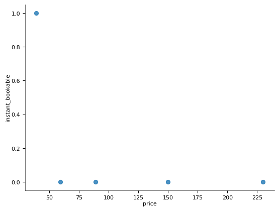

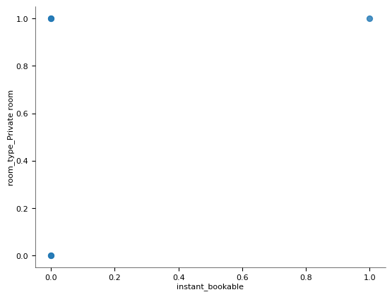

Time series

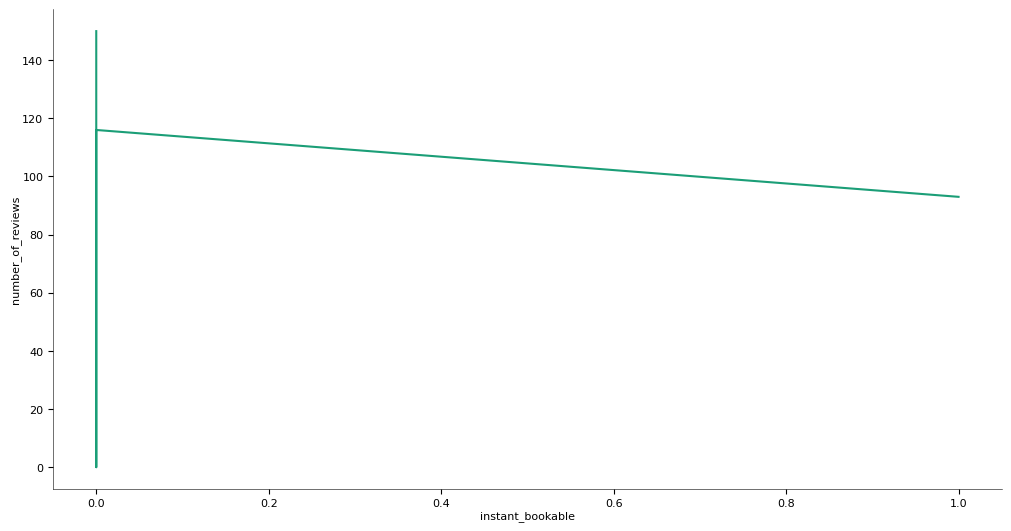

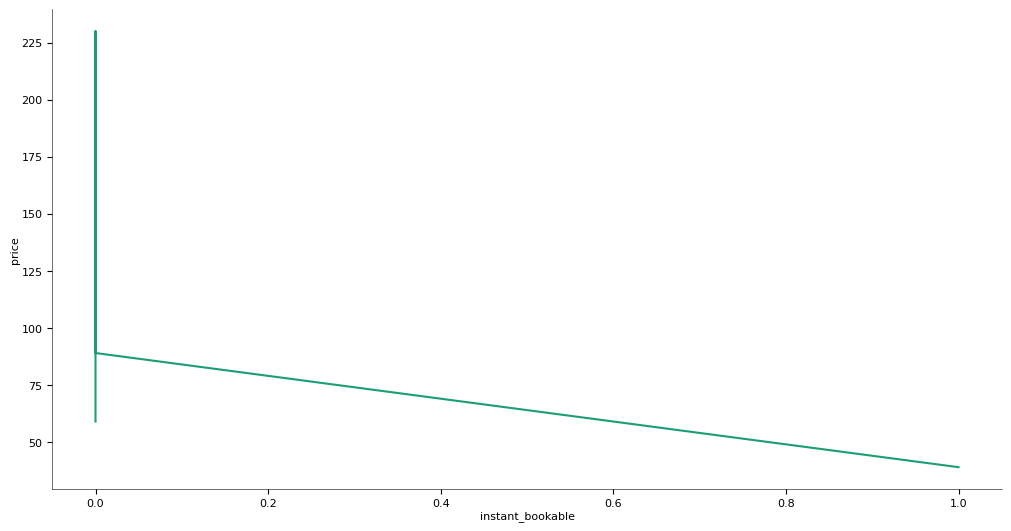

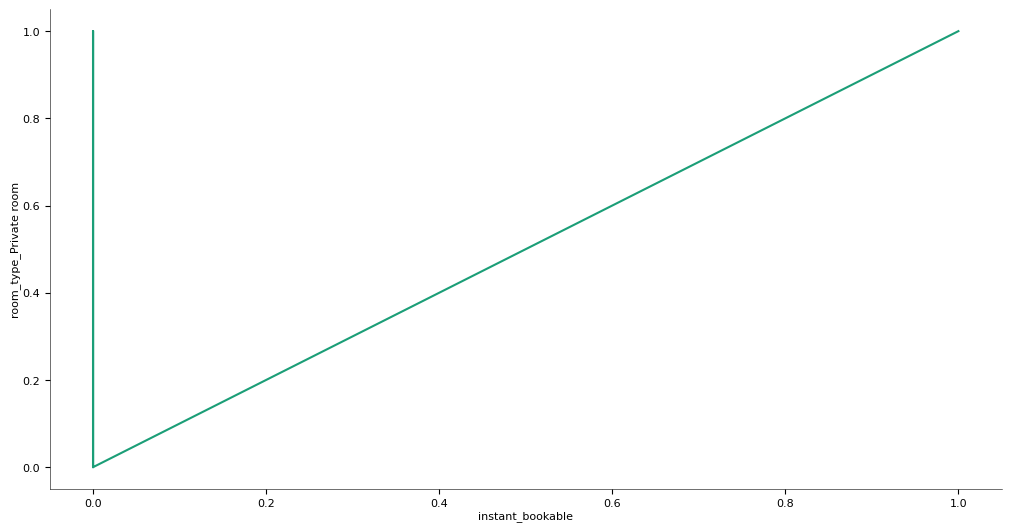

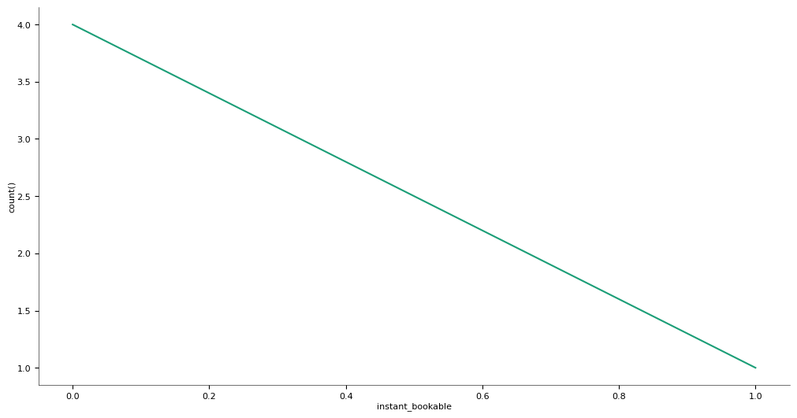

Values

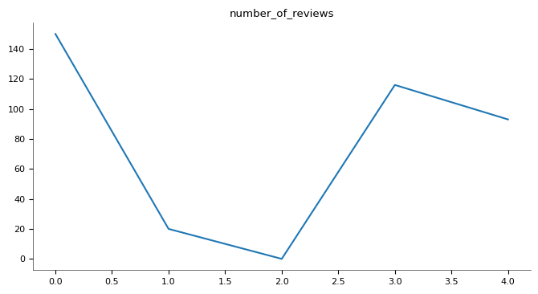

[3 more figures not shown]

```python
df = airbnb.copy()


df = df[['number_of_reviews', 'price', 'room_type', 'instant_bookable']].dropna()


df['number_of_reviews'] = df['number_of_reviews'].clip(upper=150)


df['instant_bookable'] = df['instant_bookable'].map({'t': 1, 'f': 0})


df = pd.get_dummies(df, columns=['room_type'], drop_first=True)


df = df.astype(int)


df.head()
```

## Poisson Regression via MLE (Airbnb Data)

We now fit a Poisson regression model to the Airbnb data using Maximum Likelihood Estimation (MLE). Our target variable is `number_of_reviews`, and our predictors include:

- `price`: the listing’s price per night
- `instant_bookable`: whether the listing can be booked instantly
- `room_type_Private room`: dummy variable for private rooms
- `room_type_Shared room`: dummy variable for shared rooms

We first define the Poisson log-likelihood function, then use `scipy.optimize.minimize()` to estimate the model parameters. The optimization method used is L-BFGS-B, which is suitable for constrained and large-scale problems.

```python
import numpy as np
import pandas as pd
from scipy.optimize import minimize
from scipy.special import gammaln
from sklearn.preprocessing import StandardScaler


df = airbnb.copy()
df = df[['number_of_reviews', 'price', 'room_type', 'instant_bookable']].dropna()
df = df[(df['number_of_reviews'] > 0) & (df['number_of_reviews'] < 150)]


df['instant_bookable'] = df['instant_bookable'].map({'t': 1, 'f': 0})
df = pd.get_dummies(df, columns=['room_type'], drop_first=True)


scaler = StandardScaler()
df['price'] = scaler.fit_transform(df[['price']])


X_airbnb = df.drop(columns=['number_of_reviews']).copy()
X_airbnb.insert(0, 'intercept', 1)
X_airbnb = X_airbnb.astype(float).values
y_airbnb = df['number_of_reviews'].values



def poisson_log_likelihood(beta, X, y):
    linear = np.dot(X, beta)
    lambda_ = np.exp(np.clip(linear, -250, 250))
    log_lik = np.sum(y * np.log(lambda_ + 1e-9) - lambda_ - gammaln(y + 1))
    return -log_lik


beta_init = np.random.normal(0.1, 0.01, size=X_airbnb.shape[1])

result_airbnb = minimize(
    poisson_log_likelihood,
    beta_init,
    args=(X_airbnb, y_airbnb),
    method='L-BFGS-B',
    options={'disp': True, 'maxiter': 1000}
)


print("Success:", result_airbnb.success)
print("Log-likelihood:", -result_airbnb.fun)
print("Estimated Coefficients:", result_airbnb.x.round(4))
```

```
Success: True
Log-likelihood: -463759.9049083586
Estimated Coefficients: [ 2.9149e+00  7.0000e-04  2.8430e-01 -7.3900e-02 -2.3380e-01]
```

```python
import statsmodels.api as sm


X_df = df.drop(columns=['number_of_reviews']).copy()
X_df = sm.add_constant(X_df)
X_df = X_df.astype(float)  # <-- FIX


y = df['number_of_reviews'].astype(float)

glm_model = sm.GLM(y, X_df, family=sm.families.Poisson()).fit()


print(glm_model.summary())
```

```
                 Generalized Linear Model Regression Results
==============================================================================
Dep. Variable:      number_of_reviews   No. Observations:                30809
Model:                            GLM   Df Residuals:                    30804
Model Family:                 Poisson   Df Model:                            4
Link Function:                    Log   Scale:                          1.0000
Method:                          IRLS   Log-Likelihood:            -4.6376e+05
Date:                Thu, 08 May 2025   Deviance:                   8.0587e+05
Time:                        03:00:43   Pearson chi2:                 1.10e+06
No. Iterations:                     5   Pseudo R-squ. (CS):             0.2533
Covariance Type:            nonrobust
==========================================================================================
                             coef    std err          z      P>|z|      [0.025      0.975]
------------------------------------------------------------------------------------------
const                      2.9149      0.002   1490.045      0.000       2.911       2.919
price                      0.0007      0.001      0.475      0.634      -0.002       0.003
instant_bookable           0.2843      0.003     92.291      0.000       0.278       0.290
room_type_Private room    -0.0739      0.003    -26.404      0.000      -0.079      -0.068
room_type_Shared room     -0.2338      0.009    -26.596      0.000      -0.251      -0.217
==========================================================================================
```

## Comparison with Built-in Poisson Regression

To validate our manual MLE results, we fit the same model using Python’s built-in `GLM()` function from the `statsmodels` library. The results are nearly identical across all variables:

- Listings with `instant_bookable = 1` receive significantly more reviews (β ≈ 0.284).
- `room_type_Shared room` and `room_type_Private room` have negative coefficients, indicating fewer reviews compared to the reference category (entire home/apt).
- The intercept and other values match our MLE solution to four decimal places.

This confirms the accuracy of our hand-coded log-likelihood and optimization procedure, and demonstrates that MLE results are consistent with standard software implementations.

## Conclusion

This assignment demonstrated how to apply Maximum Likelihood Estimation (MLE) to fit Poisson regression models on two distinct datasets: Blueprinty customer data and Airbnb listings from New York City.

In **Part 1**, we successfully wrote and optimized a custom Poisson log-likelihood function to model the number of patents filed by customers. Our hand-coded results closely matched the output from the built-in `GLM()` model, confirming the accuracy of our implementation.

In **Part 2**, we cleaned and filtered the Airbnb data, selected appropriate predictors, and again fit a Poisson regression model using both MLE and `GLM()`. The results showed that:

- Instant bookable listings receive more reviews,
- Shared and private rooms receive fewer reviews compared to entire apartments,
- And price (when standardized) had minimal impact.

This assignment helped reinforce key concepts in statistical modeling, such as log-linear models, numerical optimization, and the practical challenges of real-world data preparation. It also demonstrated how well theoretical tools like MLE align with robust, high-level libraries used in professional data science workflows.